[O’Hara on GitHub](https://github.com/oharac)

# Process nutrient pollution

Compiled on Fri Dec 10 17:30:42 2021 by ohara

```r
knitr::opts_chunk$set(echo = TRUE, message = FALSE, warning = FALSE)

library(raster)
library(sf)
library(tidyverse)
library(here)
library(RColorBrewer)

source(here('common_fxns.R'))
source('stressor_fxns.R') ### in same dir as this Rmd
```

# 1 Summary

Gather nutrient-related stressor layers and process to the CRS for this analysis: Mollweide, 10 km x 10 km. Identify gapfill needs if necessary.

# 2 Data

All files are located on Mazu, starting from `/home/shares/ohi/` unless otherwise noted.

## 2.1 Agricultural-based nutrient pollution

Nutrient pollution from OHI 2021 plume model

- This appears to be absolute amounts (tonnes) per cell, so can be normalized to an intensity (tonnes per km<sup>2</sup> e.g.) to be combined with wastewater data.
- dir: `git-annex/globalprep/prs_land-based_nutrient/v2021/output/N_plume`
  - file: `pourpoints_crop_manure_leached_volt_N_2019_joined.tif`
- See OHI processing scripts for details: https://github.com/OHI-Science/ohiprep_v2021/tree/gh-pages/globalprep/prs_land-based_nutrient/v2021

## 2.2 Wastewater

From the Wastewater project

- Get dataset from KNB: https://knb.ecoinformatics.org/view/doi%3A10.5063%2FF76B09. It has been downloaded to Mazu (see below). According to metadata:
  - > Each pixel is grams N.
  - Use this note from Mel to make sure the numbers are in the same ballpark between ag and wastewater:
    - > Our model indicates that wastewater adds 6.2Tg nitrogen into coastal waters, which is approximately 40% of total nitrogen from agriculture.
    - A quick check shows that this layer results in about 4.5Tg of N, about 33% of that from agriculture-based N, so ballpark.
- dir: spp vuln mapping directory, `/stressors/nutrient/wastewater`
  - file: `global_effluent_2015_tot_N.tif`

## 2.3 Aquaculture pollution

From the Food Systems project

- see https://github.com/OHI-Science/food_systems/tree/master/aquaculture/marine/
  - > These values, in the scheme of these kinds of things, should be fairly accurate (the models are pretty simple and N flows directly into the marine system). I would check the units to make sure they are the same as other datasources (I think they are tonnes/cell here).
  - Looks like the nutrient pollution from aquaculture layers are on Aurora:
    - `/home/shares/food-systems/Food_footprint/all_food_systems/datalayers`

# 3 Methods

For each stressor layer, reproject to 10 km Mollweide CRS and mask to ocean cells. Layers that are in tonnes of N per cell must be converted to t/km<sup>2</sup> prior to reprojecting. Sum across all sources (verifying units carefully) then rescale based on a quantile e.g., 99.9%.

```r
here_ohi <- function(f = '', ...) {
  f <- paste(f, ..., sep = '/')
  f <- stringr::str_replace_all(f, '\\/+', '/')
  sprintf('/home/shares/ohi/%s', f)
}

### Load ocean proportion in Mollweide 10 km x 10 km (analysis CRS and res)
ocean_rast <- raster(here('_spatial/ocean_area_mol.tif'))

### ocean area (in km^2) in 10 km x 10 km Mollweide
ocean_area_mol <- ocean_rast * 100

### load ocean area (in km^2) in 0.1 deg WGS84 (for converting values to
### intensities prior to reprojecting)
ocean_area_0.1deg <- raster(here('_spatial/ocean_area_wgs84_0.1deg.tif'))

### Code to create ocean area raster at 0.1 degree:
# base_rast_0.01deg <- raster(ext = extent(c(-180, 180, -90, 90)),
#                            res = 0.01, crs = '+init=epsg:4326')
# ocean_mask_sf <- read_sf(here('_spatial/ne_10m_ocean/ne_10m_ocean.shp'))
# ocean_rast_0.01deg <- fasterize::fasterize(ocean_mask_sf, base_rast_0.01deg)
# ocean_rast_0.1deg <- aggregate(ocean_rast_0.01deg,
#                                progress = 'text',
#                                fact = 10, fun = sum)
# ocean_rast_0.1deg <- ocean_rast_0.1deg / 100
# ocean_area_0.1deg <- ocean_rast_0.1deg * raster::area(ocean_rast_0.1deg)
# writeRaster(ocean_area_0.1deg, here('_spatial/ocean_area_wgs84_0.1deg.tif'))
```

## 3.1 Nutrient pollution from OHI 2021 plume model

This is in tonnes per cell (0.5 arc-minute cell). Convert to tonnes per km^2, aggregate, reproject to 10 km x 10 km Mollweide. This will still be tonnes per km^2.

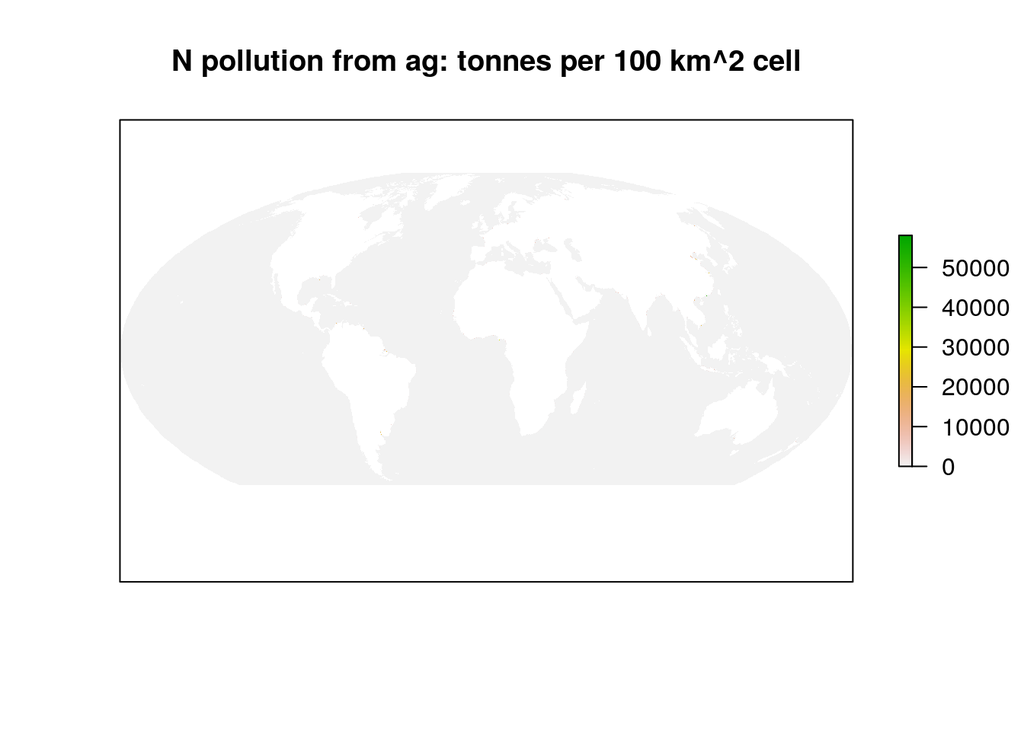

```r
N_agr_out_f <- here_anx('stressors/nutrient/nutrient_agr_N_per_km2_mol.tif')
### unlink(N_agr_out_f)

if(!file.exists(N_agr_out_f)) {
  N_agr_raw_f <- here_ohi('git-annex/globalprep/prs_land-based_nutrient',
                     'v2021/output/N_plume',
                     'pourpoints_crop_manure_leached_volt_N_2019_joined.tif')
  N_agr_raw_r <- raster(N_agr_raw_f)
  # class      : RasterLayer
  # dimensions : 16981, 43465, 738079165  (nrow, ncol, ncell)
  # resolution : 0.008333333, 0.008333333  (x, y)
  # extent     : -181.0083, 181.2, -57.33333, 84.175  (xmin, xmax, ymin, ymax)
  # crs        : +proj=longlat +datum=WGS84 +no_defs
  # source     : pourpoints_crop_manure_leached_volt_N_2019_joined.tif
  # names      : pourpoints_crop_manure_leached_volt_N_2019_joined

  ### mask to just ocean cells to avoid land-based zeros from influencing mean;
  ### first transform to N/km^2
  ocean_mask_sf <- read_sf(here('_spatial/ne_10m_ocean/ne_10m_ocean.shp'))
  ocean_mask_r <- fasterize::fasterize(ocean_mask_sf, N_agr_raw_r)
  masked_r <- mask(N_agr_raw_r, ocean_mask_r, progress = 'text')
  area_r <- raster::area(N_agr_raw_r, progress = 'text')
  N_per_km2_r <- masked_r / area_r

  ### Aggregate up to ~ 10 km, 0.1°, then reproject
  agg_r <- aggregate(N_per_km2_r, fact = 12, fun = 'mean', progress = 'text')
  agg_r_mol <- projectRaster(agg_r, ocean_rast, progress = 'text')

  ### N per km^2 times ocean area --> total N per cell
  N_agr_mol_r <- agg_r_mol * ocean_rast * 100

  # sum(values(N_agr_mol_r), na.rm = TRUE) # 13,486,464
  # sum(values(masked_r), na.rm = TRUE)    # 13,452,581
  ### pretty close!

  ### write out to temp file for later combo with wastewater and aquaculture
  writeRaster(N_agr_mol_r, N_agr_out_f, overwrite = TRUE)

}

r <- raster(N_agr_out_f)

plot(r, axes = FALSE,
     main = 'N pollution from ag: tonnes per 100 km^2 cell')
```

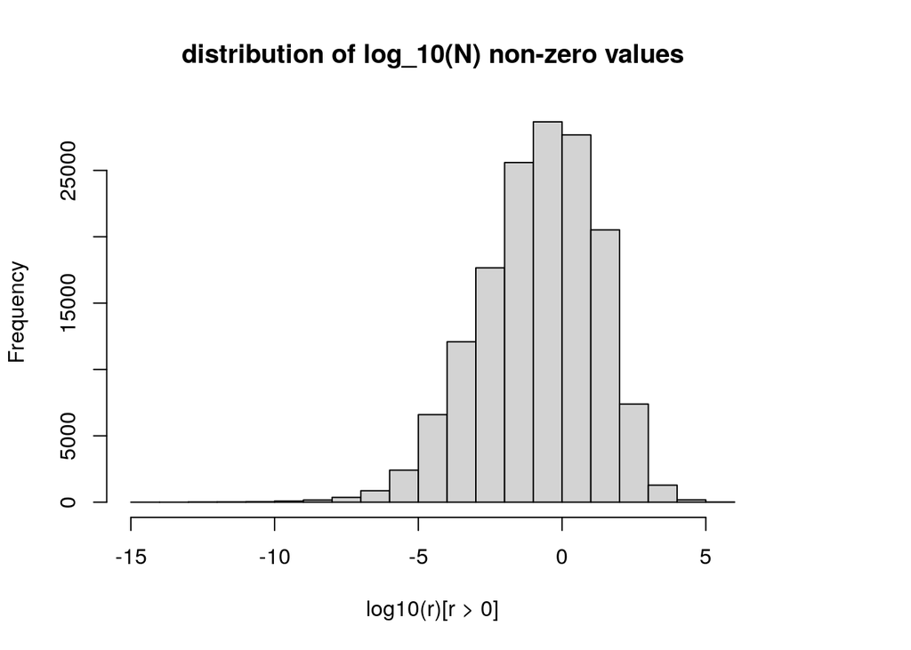

```r
hist(log10(r)[r > 0], main = 'distribution of log_10(N) non-zero values')
```

## 3.2 Nutrient pollution from wastewater plume

These values are in grams of N per pixel. Convert to tonnes (1e6 g = 1 t).

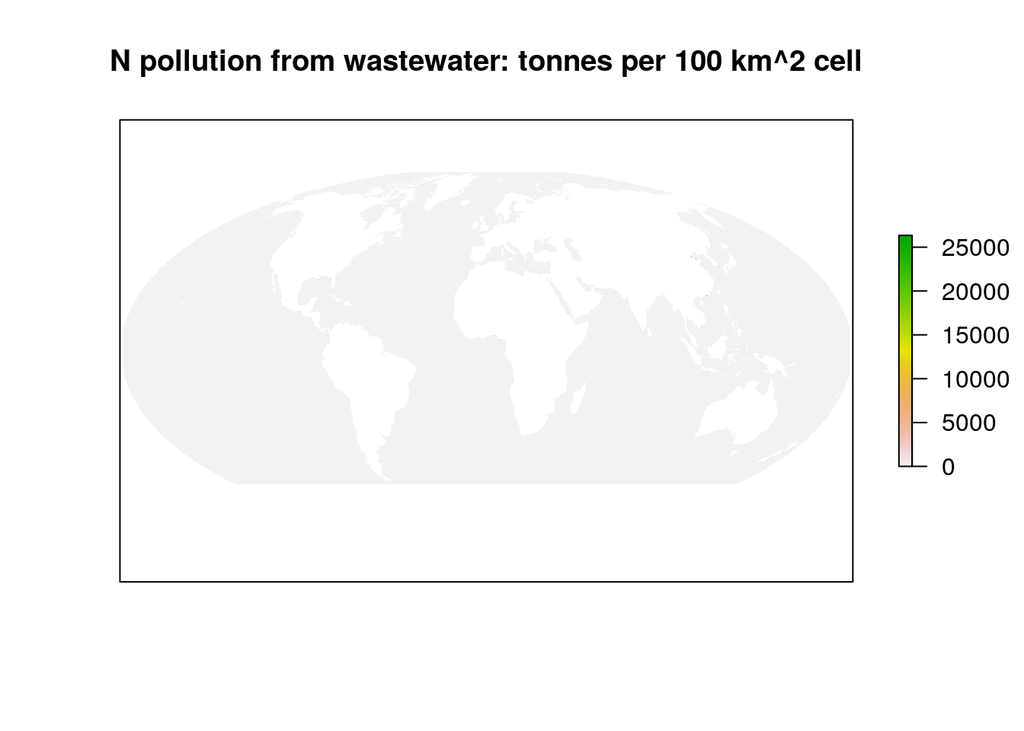

```r
N_ww_out_f <- here_anx('stressors/nutrient/nutrient_wastewater_N_per_km2_mol.tif')
### unlink(N_ww_out_f)

if(!file.exists(N_ww_out_f)) {
  N_ww_raw_f <- here_anx('stressors/nutrient/wastewater',
                     'global_effluent_2015_tot_N.tif')
  N_ww_raw_r <- raster(N_ww_raw_f)
  # class      : RasterLayer
  # dimensions : 17068, 43737, 746503116  (nrow, ncol, ncell)
  # resolution : 0.008333333, 0.008333333  (x, y)
  # extent     : -182.225, 182.25, -57.18333, 85.05  (xmin, xmax, ymin, ymax)
  # crs        : +proj=longlat +datum=WGS84 +no_defs
  # source     : global_effluent_2015_tot_N.tif
  # names      : global_effluent_2015_tot_N
  #
  # summary(values(N_ww_raw_r))
  # Min.    1st Qu.     Median       Mean    3rd Qu.       Max.
  # -618          0          0       6708          0 1812330880

  ### Convert from grams N into tonnes N (i.e., Mg):
  N_ww_tonnes_r <- N_ww_raw_r / 1e6

  ### mask to just ocean cells to avoid land-based zeros from influencing mean;
  ### first transform to N/km^2
  ocean_mask_sf <- read_sf(here('_spatial/ne_10m_ocean/ne_10m_ocean.shp'))
  ocean_mask_r <- fasterize::fasterize(ocean_mask_sf, N_ww_tonnes_r)
  masked_r <- mask(N_ww_tonnes_r, ocean_mask_r, progress = 'text')
  area_r <- raster::area(N_ww_tonnes_r, progress = 'text')
  N_per_km2_r <- masked_r / area_r

  ### Aggregate up to ~ 10 km, 0.1°, then reproject
  agg_r <- aggregate(N_per_km2_r, fact = 12, fun = 'mean', progress = 'text')
  agg_r_mol <- projectRaster(agg_r, ocean_rast, progress = 'text')

  ### N per km^2 times ocean area --> total N per cell
  N_ww_mol_r <- agg_r_mol * ocean_rast * 100

  # sum(values(N_ww_mol_r), na.rm = TRUE) # 4,583,082
  # sum(values(masked_r), na.rm = TRUE)   # 4,586,456
  ### pretty close!

  ### write out to temp file for later combo with wastewater and aquaculture
  writeRaster(N_ww_mol_r, N_ww_out_f)

}

r <- raster(N_ww_out_f)

plot(r, axes = FALSE,
     main = 'N pollution from wastewater: tonnes per 100 km^2 cell')
```

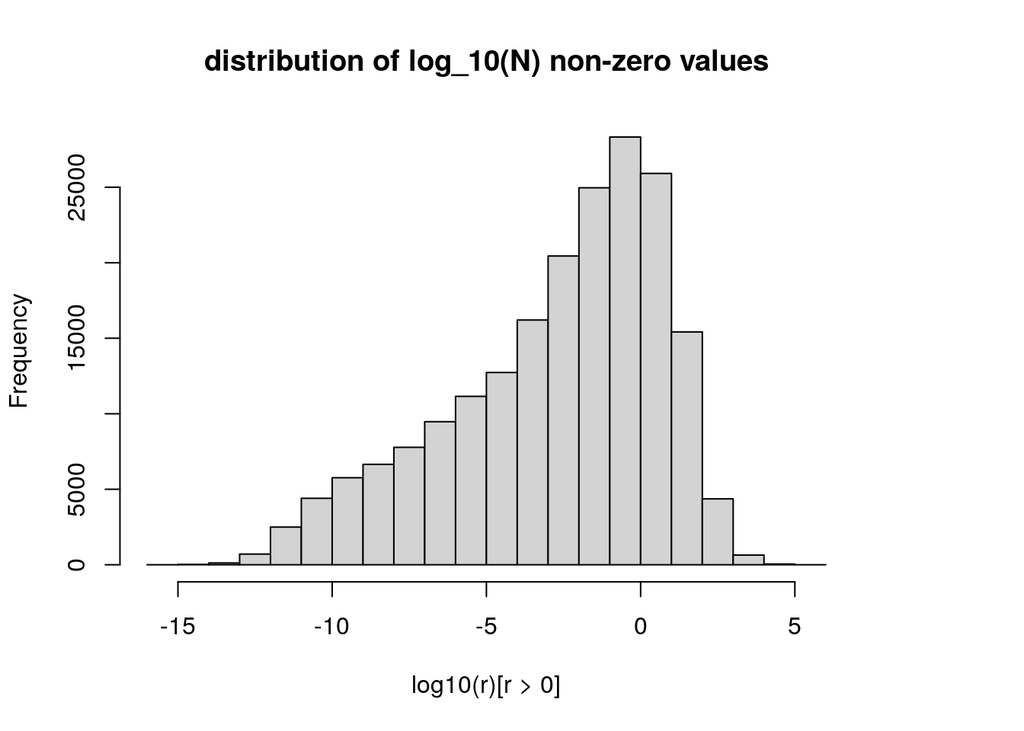

```r
hist(log10(r)[r > 0], main = 'distribution of log_10(N) non-zero values')
```

## 3.3 Nutrient pollution from aquaculture

These values are in tonnes of N per pixel.

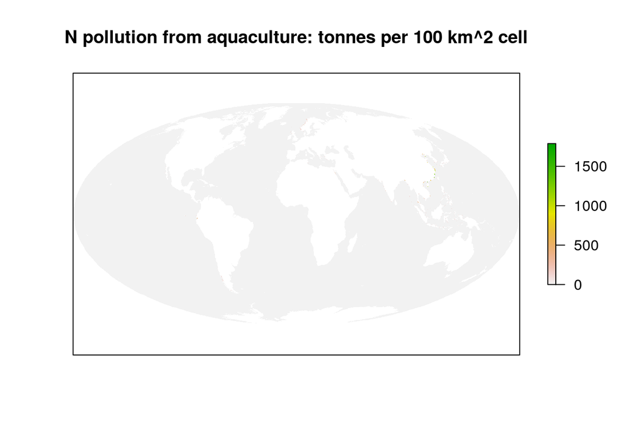

```r
N_aq_out_f <- here_anx('stressors/nutrient/nutrient_aquaculture_N_per_km2_mol.tif')
### unlink(N_aq_out_f)

if(!file.exists(N_aq_out_f)) {
  N_aq_raw_fs <- list.files(here_anx('stressors/nutrient/aquaculture'),
                            full.names = TRUE)
  N_aq_raw_stack <- raster::stack(N_aq_raw_fs)
  # class      : RasterStack
  # dimensions : 2160, 4320, 9331200, 6  (nrow, ncol, ncell, nlayers)
  # resolution : 0.08333333, 0.08333333  (x, y)
  # extent     : -180, 180, -90, 90  (xmin, xmax, ymin, ymax)
  # crs        : +proj=longlat +datum=WGS84 +no_defs
  # names      : marine_bi//_nutrientN, marine_cr//_nutrientN, marine_ma//_nutrientN, marine_sa//_nutrientN, marine_sh//_nutrientN, marine_tu//_nutrientN
  # min values :                     0,                     0,                     0,                     0,                     0,                     0
  # max values :              505.5862,              255.1060,             4346.8144,              404.0540,             1511.8945,             1019.5875

  ### mask to just ocean cells to avoid land-based zeros from influencing mean;
  ### first transform to N/km^2
  ocean_mask_sf <- read_sf(here('_spatial/ne_10m_ocean/ne_10m_ocean.shp'))
  ocean_mask_r <- fasterize::fasterize(ocean_mask_sf, N_aq_raw_stack[[1]])
  masked_stack <- mask(N_aq_raw_stack, ocean_mask_r, progress = 'text')
  area_r <- raster::area(N_aq_raw_stack[[1]], progress = 'text')
  N_per_km2_stack <- masked_stack / area_r

  ### cells are already nearly 0.1 degree - don't aggregate, just reproject
  N_per_km2_mol_stack <- projectRaster(N_per_km2_stack, ocean_rast, progress = 'text')

  ### N per km^2 times ocean area --> total N per cell
  N_per_cell_mol_r <- N_per_km2_mol_stack * ocean_rast * 100

  ### check by layer:
  # sum(values(masked_stack[[1]]), na.rm = TRUE)       #  39504.6
  # sum(values(N_per_cell_mol_r[[1]]), na.rm = TRUE)   #  34561.4
  # sum(values(masked_stack[[2]]), na.rm = TRUE)       #  18933.4
  # sum(values(N_per_cell_mol_r[[2]]), na.rm = TRUE)   #  16883.5
  # sum(values(masked_stack[[3]]), na.rm = TRUE)       # 372307.6
  # sum(values(N_per_cell_mol_r[[3]]), na.rm = TRUE)   # 324416.7
  # sum(values(masked_stack[[4]]), na.rm = TRUE)       #  77999.2
  # sum(values(N_per_cell_mol_r[[4]]), na.rm = TRUE)   #  66989.3
  # sum(values(masked_stack[[5]]), na.rm = TRUE)       # 228890.6
  # sum(values(N_per_cell_mol_r[[5]]), na.rm = TRUE)   # 200364.9
  # sum(values(masked_stack[[6]]), na.rm = TRUE)       #   4234.6
  # sum(values(N_per_cell_mol_r[[6]]), na.rm = TRUE)   #   3842.5
  ### full stack:
  # sum(values(masked_stack), na.rm = TRUE)            # 741870.3
  # sum(values(N_per_cell_mol_r), na.rm = TRUE)        # 647058.5
  ### not as close as I'd like

  ### summarize all
  N_aq_mol_r <- calc(N_per_cell_mol_r, sum)

  ### write out to temp file for later combo with wastewater and aquaculture
  writeRaster(N_aq_mol_r, N_aq_out_f)

}

r <- raster(N_aq_out_f)

plot(r, axes = FALSE,
     main = 'N pollution from aquaculture: tonnes per 100 km^2 cell')
```

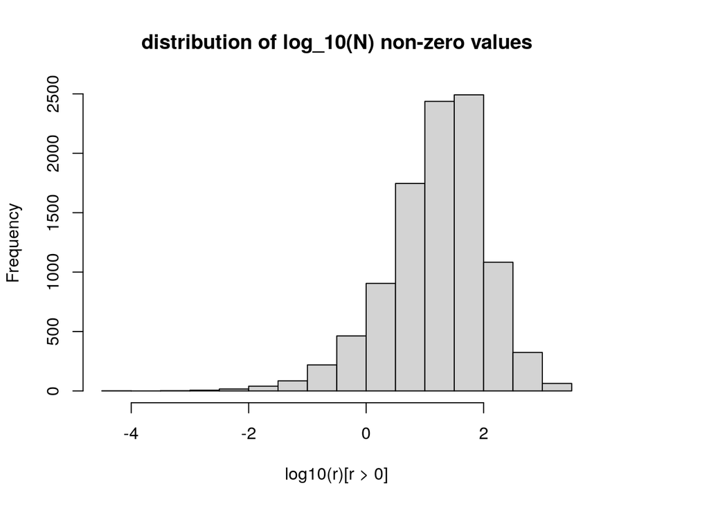

```r
hist(log10(r)[r > 0], main = 'distribution of log_10(N) non-zero values')
```

## 3.4 Combine N pollution and rescale

Combine nitrogen (tonnes per 10 km x 10 km cell) across agriculture, wastewater, and aquaculture sources; then rescale based on a quantile to reduce the effects of extreme outliers. This is currently NOT log-transformed.

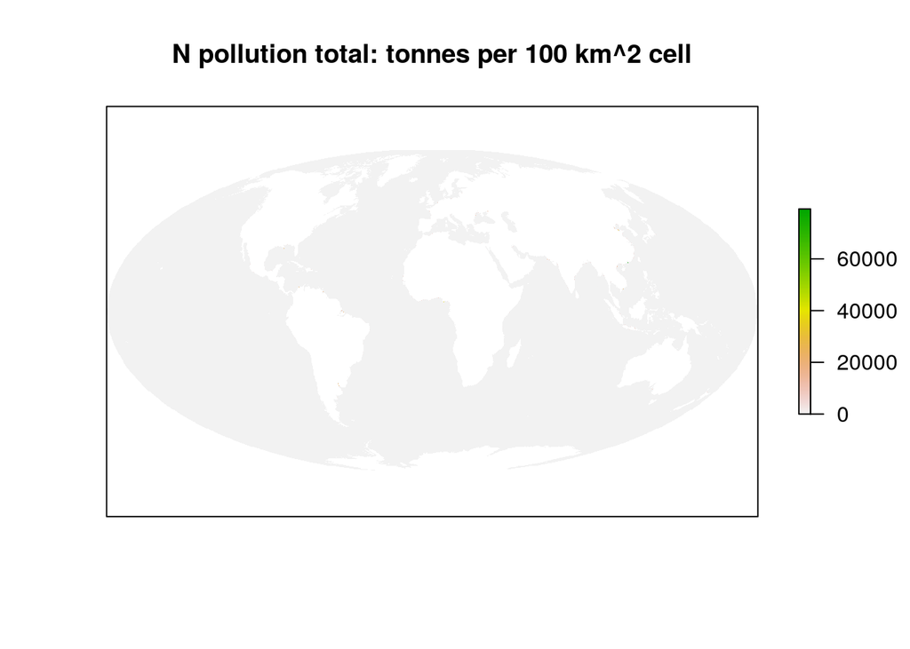

```r
N_layers <- list.files(here_anx('stressors/nutrient'),
                       pattern = 'N_per_km2_mol.tif',
                       full.names = TRUE)
N_stack <- stack(N_layers)
N_rast <- calc(N_stack, sum)

### fill southern NAs from ag rast with 0, then re-mask
values(N_rast)[is.na(values(N_rast))] <- 0
values(N_rast)[values(N_rast) < 0] <- 0 ### drop neg values
N_rast <- mask(N_rast, ocean_rast)

plot(N_rast, axes = FALSE,
     main = 'N pollution total: tonnes per 100 km^2 cell')
```

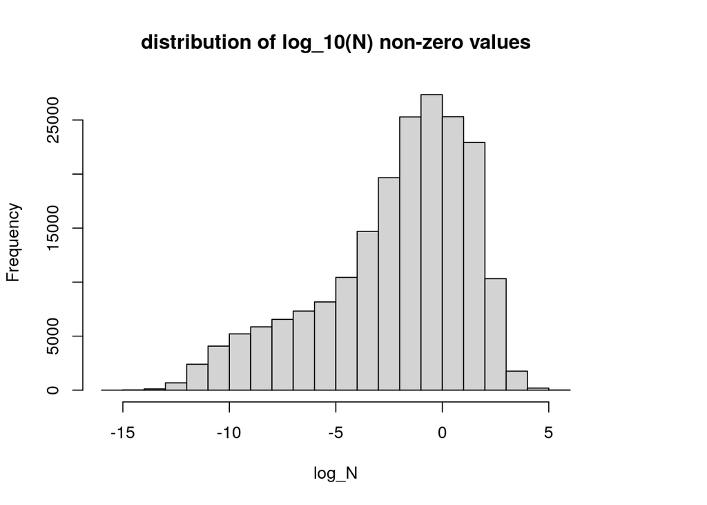

```r
log_N <- log10(N_rast)[N_rast > 0]
hist(log_N, main = 'distribution of log_10(N) non-zero values')
```

```r
### Rescale
quantile(values(N_rast), c(0.9, 0.95, 0.99, 0.999, 1.0), na.rm = TRUE) %>%
  knitr::kable()
```

[output not shown]